# 320FINALdeliverable

## What impacts a songs streaming success on spotify?

CMSC320 2026 Data Science Project Sandra Sumesh

## A: Project idea

I chose this project idea because of my interest in music and music production, making this an engaging domain for me to explore.

## B: Dataset Curation and Preprocessing

I did all dataset curation and preprocessing including: loading the dataset, parseing data, organizing and replacing missing values and data.

## C: Data Exploration and Summary Statistics

I explored key distributions, identified highly right-skewed streaming data, and discovered a strong $r = 0.80$ correlation between Spotify playlist placements and total stream counts.

## D: ML Algorithm Design/Development

I designed a multiple linear regression model on a log-log scale to simultaneously evaluate how Spotify playlisting, Shazam counts, YouTube views, and TikTok views predict final streaming success.

## E: ML Algorithm Training and Test Data Analysis

I split the dataset into training and testing sets to evaluate the model on unseen data, successfully training an Ordinary Least Squares (OLS) model that achieved an $R^2$ of $0.652$.

## F: Visualization, Result Analysis, Conclusion

I visualized the model's performance using actual-vs-predicted and residual plots, concluding that while playlisting and Shazam counts are highly significant drivers of streams, raw TikTok views are not statistically significant.

## G: Final Tutorial Report Creation

I compiled my entire coding workflow, data cleaning decisions, and statistical insights into a structured final tutorial report designed to educate both music fans and industry professionals.

## Introduction

This dataset is about the most streamed spotify songs of 2024. It interested me because I have always liked observing music charts and seeing the patterns in which songs get popular and gain the most streams. I was an avid spotify user for many years, and I am very comfortable with its platform and music charts/rankings. Through this analysis, I am trying to discover what factors may contribute to the increase in streams of a song. These questions are important because having this data allows artists and music labels to be informed on the best strategies to use when releasing music for optimal popularity. Additionally, it reveals broader cultural attidues about how audiences respond to certain media, beyond just music. This analysis can keep all industries and businesses inform on making smart decisons when it comes to content promotion, marketing strategy, and what drives engagement from an audience.

## Data Curation

The dataset I used lists a comprehensive compilation of the most streamed songs on Spotify in 2024. It provides insights into each track's attributes, popularity, and presence on various music platforms. The dataset includes information such as track name, artist, release date, ISRC, streaming statistics, and presence on platforms like YouTube, TikTok, and more. Nidula Elgiriyewithana. (2024). *Most Streamed Spotify Songs 2024* [Dataset]. Kaggle. https://doi.org/10.34740/KAGGLE/DSV/8700156

```python
import pandas as pd
import numpy as np
import matplotlib.pyplot as plt
import seaborn as sns
from scipy import stats
import sqlite3

#DATA PREPROCESSING
#load
df = pd.read_csv("/Users/sandrasumesh/Downloads/cmsc320/Most Streamed Spotify Songs 2024.csv", encoding='latin-1')
#parse
df['Spotify Streams'] = df['Spotify Streams'].astype(str).str.replace(',', '').apply(pd.to_numeric, errors='coerce')
df['Spotify Playlist Count'] = df['Spotify Playlist Count'].astype(str).str.replace(',', '').apply(pd.to_numeric, errors='coerce')
df['YouTube Views'] = df['YouTube Views'].astype(str).str.replace(',', '').apply(pd.to_numeric, errors='coerce')
df['TikTok Views'] = df['TikTok Views'].astype(str).str.replace(',', '').apply(pd.to_numeric, errors='coerce')
df['Shazam Counts'] = df['Shazam Counts'].astype(str).str.replace(',', '').apply(pd.to_numeric, errors='coerce')
df['Release Date'] = pd.to_datetime(df['Release Date'], errors='coerce')
#missing values
df = df.dropna(subset=['Spotify Streams', 'Track'])
df.fillna(df.median(numeric_only=True), inplace=True)
#organize
conn = sqlite3.connect("/Users/sandrasumesh/Downloads/cmsc320/spotify_data.db")
df.to_sql("spotify_songs", conn, if_exists='replace', index=False)
```

```
4487
```

## Exploratory Data Analysis

This section highights three data trends I noticed and the conclusions I drew from them.

### Distribution of Spotify Streams

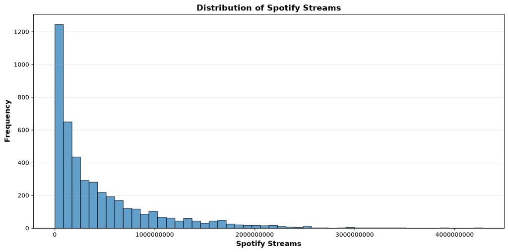

```python
#plot
plt.figure(figsize=(12, 6))
plt.hist(df['Spotify Streams'], bins=50,  edgecolor='black', alpha=0.7)
plt.xlabel('Spotify Streams', fontsize=12, fontweight='bold')
plt.ylabel('Frequency', fontsize=12, fontweight='bold')
plt.title('Distribution of Spotify Streams', fontsize=14, fontweight='bold')
plt.ticklabel_format(style='plain', axis='x')
plt.grid(True, alpha=0.3, axis='y')
plt.tight_layout()
plt.show()
```

Spotify streams show a highly right-skewed distribution. This indicates that the majority of songs in this dataset have a relatively modest stream count. A very small numnber of songs have a massive number of streams, pulling the tail of the distribution to the right. Those extreme outliers are causing the mean to be higher than the median. The few viral hits skew the average stream count to be high, even though most songs don't come close to that number.

### Streams and Playlist Placement

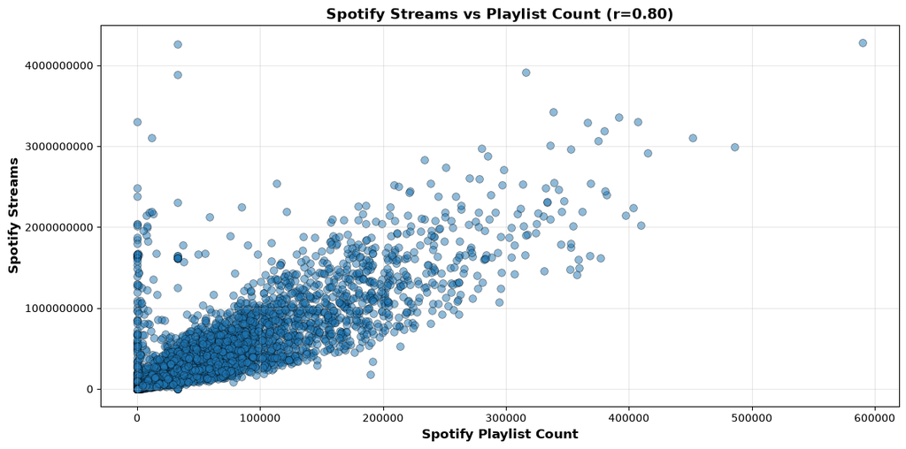

```python
numeric_cols = ['Spotify Streams', 'Spotify Playlist Count', 'YouTube Views', 'TikTok Views', 'Shazam Counts']

df_numeric = df[numeric_cols].dropna()

plt.figure(figsize=(12, 6))
plt.scatter(df_numeric['Spotify Playlist Count'], df_numeric['Spotify Streams'],
            alpha=0.5, s=50, edgecolor='black', linewidth=0.5)
plt.xlabel('Spotify Playlist Count', fontsize=12, fontweight='bold')
plt.ylabel('Spotify Streams', fontsize=12, fontweight='bold')
plt.title('Spotify Streams vs Playlist Count (r=0.80)', fontsize=14, fontweight='bold')
plt.ticklabel_format(style='plain', axis='both')
plt.grid(True, alpha=0.3)
plt.tight_layout()
plt.show()
```

The scatter pattern has an r value of 0.80. This indicates a strong positive correlation, which is displayed on the plot with an upward trend. As playlist counts increase, the amount of streams for that song increases as well. We can determine from this that a song added to a playlist, whether its user-made or spotify's own curated playlists, is more likely to be listened to and streamed. It's also possible that already popular songs get added to more playlists as a result of their success, meaning the relationship could reinforce itself in both directions.

### The Explicit vs. Non-Explicit Track Performance

```
results:
t-statistic: -0.1925
p-value: 0.847328
no statistically significant difference (p >= 0.05)
```

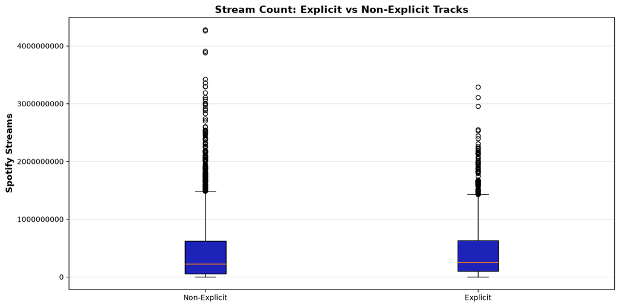

```python
explicit = df[df['Explicit Track'] == 1]['Spotify Streams'].dropna()
non_explicit = df[df['Explicit Track'] == 0]['Spotify Streams'].dropna()

t_stat, p_value = stats.ttest_ind(explicit, non_explicit)
print(f"\nresults:")
print(f"t-statistic: {t_stat:.4f}")
print(f"p-value: {p_value:.6f}")

if p_value < 0.05:
    print("statistical difference (p < 0.05)")
else:
    print("no statistically significant difference (p >= 0.05)")

fig = plt.figure(figsize=(12, 6))
data_to_plot = [non_explicit, explicit]
bp = plt.boxplot(data_to_plot, tick_labels=['Non-Explicit', 'Explicit'], patch_artist=True)
for patch in bp['boxes']:
    patch.set_facecolor("#1D22B9")
plt.ylabel('Spotify Streams', fontsize=12, fontweight='bold')
plt.title('Stream Count: Explicit vs Non-Explicit Tracks', fontsize=14, fontweight='bold')
plt.ticklabel_format(style='plain', axis='y')
plt.grid(True, alpha=0.3, axis='y')
plt.tight_layout()
plt.show()
```

The t-statistic and p-values are -0.19 and 0.847, respectivly. This indicates that explicit content, by itself, does not appear to meaningfully affect how many streams a song gets.

## Primary Analysis

Based on the results of my exploration, I would choose regression. This technique is ideal because our target variable, Spotify Streams, is a continuous numeric value, which eliminates classification models. Furthermore, clustering is not appropriate for this analysis because clustering identifies natural, unsupervised groupings within data rather than predicting a specific outcome. This does not align with my goal of understanding what drives stream counts up or down.

## Visualization

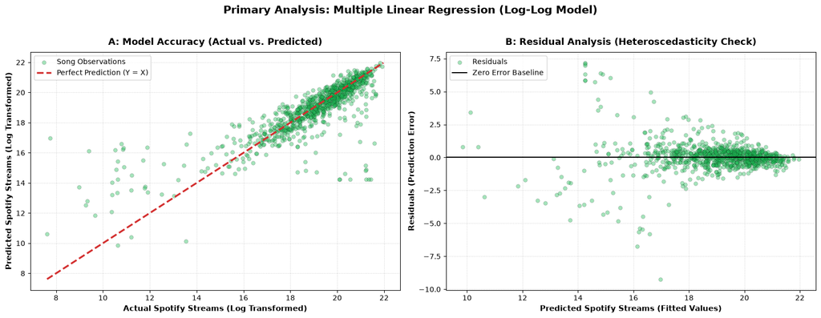

```
                            OLS Regression Results
==============================================================================
Dep. Variable:        Spotify Streams   R-squared:                       0.652
Model:                            OLS   Adj. R-squared:                  0.652
Method:                 Least Squares   F-statistic:                     1679.
Date:                Tue, 14 Jul 2026   Prob (F-statistic):               0.00
Time:                        17:07:57   Log-Likelihood:                -6112.6
No. Observations:                3589   AIC:                         1.224e+04
Df Residuals:                    3584   BIC:                         1.227e+04
Df Model:                           4
Covariance Type:            nonrobust
==========================================================================================
                             coef    std err          t      P>|t|      [0.025      0.975]
------------------------------------------------------------------------------------------
const                      6.8835      0.275     25.065      0.000       6.345       7.422
Spotify Playlist Count     0.5126      0.012     43.325      0.000       0.489       0.536
YouTube Views              0.1154      0.013      8.990      0.000       0.090       0.141
TikTok Views              -0.0097      0.010     -1.009      0.313      -0.029       0.009
Shazam Counts              0.3685      0.016     23.456      0.000       0.338       0.399
==============================================================================
Omnibus:                     1106.305   Durbin-Watson:                   2.008
Prob(Omnibus):                  0.000   Jarque-Bera (JB):            36198.360
Skew:                          -0.817   Prob(JB):                         0.00
Kurtosis:                      18.472   Cond. No.                         390.
==============================================================================

Notes:
[1] Standard Errors assume that the covariance matrix of the errors is correctly specified.
```

```python
import numpy as np
import pandas as pd
import statsmodels.api as sm
import matplotlib.pyplot as plt
from sklearn.model_selection import train_test_split

feature_cols = ['Spotify Playlist Count', 'YouTube Views', 'TikTok Views', 'Shazam Counts']
target_col = 'Spotify Streams'
df_model = df[feature_cols + [target_col]].dropna()
X = np.log1p(df_model[feature_cols])
y = np.log1p(df_model[target_col])
X = sm.add_constant(X)
X_train, X_test, y_train, y_test = train_test_split(X, y, test_size=0.2, random_state=42)
ols_model = sm.OLS(y_train, X_train).fit()
y_pred = ols_model.predict(X_test)
residuals = y_test - y_pred

fig, (ax1, ax2) = plt.subplots(1, 2, figsize=(16, 6))

# Plot A: Actual vs. Predicted
ax1.scatter(y_test, y_pred, alpha=0.4, s=30, color='#1DB954', edgecolor='black', linewidth=0.3, label='Song Observations')
min_val = min(y_test.min(), y_pred.min())
max_val = max(y_test.max(), y_pred.max())
ax1.plot([min_val, max_val], [min_val, max_val], color='#D32F2F', linestyle='--', linewidth=2.5, label='Perfect Prediction (Y = X)')
ax1.set_xlabel('Actual Spotify Streams (Log Transformed)', fontsize=11, fontweight='bold')
ax1.set_ylabel('Predicted Spotify Streams (Log Transformed)', fontsize=11, fontweight='bold')
ax1.set_title('A: Model Accuracy (Actual vs. Predicted)', fontsize=13, fontweight='bold', pad=10)
ax1.grid(True, linestyle=':', alpha=0.6)
ax1.legend(loc='upper left')

# Plot B: Residuals
ax2.scatter(y_pred, residuals, alpha=0.4, s=30, color='#1DB954', edgecolor='black', linewidth=0.3, label='Residuals')
ax2.axhline(0, color='black', linestyle='-', linewidth=1.5, label='Zero Error Baseline')
ax2.set_xlabel('Predicted Spotify Streams (Fitted Values)', fontsize=11, fontweight='bold')
ax2.set_ylabel('Residuals (Prediction Error)', fontsize=11, fontweight='bold')
ax2.set_title('B: Residual Analysis (Heteroscedasticity Check)', fontsize=13, fontweight='bold', pad=10)
ax2.grid(True, linestyle=':', alpha=0.6)
ax2.legend(loc='upper left')

plt.suptitle('Primary Analysis: Multiple Linear Regression (Log-Log Model)', fontsize=15, fontweight='bold', y=1.02)
plt.tight_layout()
plt.show()

print(ols_model.summary())
```

## Insights and Conclusions

This project helps offer clear data-driven takeaways for both casual listeners and industry experts. For a casual reader, our analysis shows that a song's popularity is not random. Instead, success across different platforms is highly connected, explaining $65.2\%$ of why a song gets streamed on Spotify. For an industry expert, the data reveals some eye trends that should shift marketing strategies.